# Root_Fungi

Wes Bickford

4/26/2017

# Root Fungi Analysis

## Rarefaction Curves

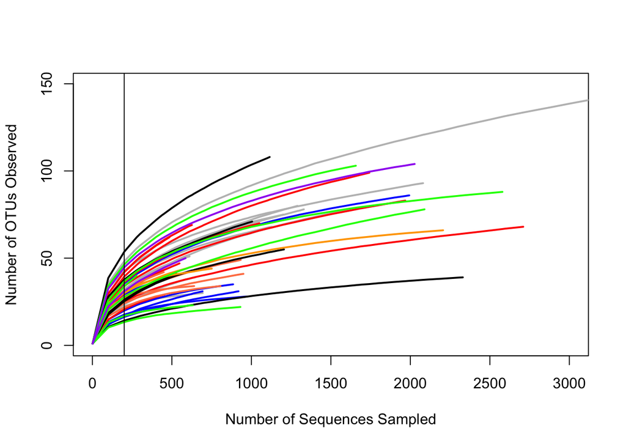

## Alpha Diversity

The following shows shannon diversity by site and lineage

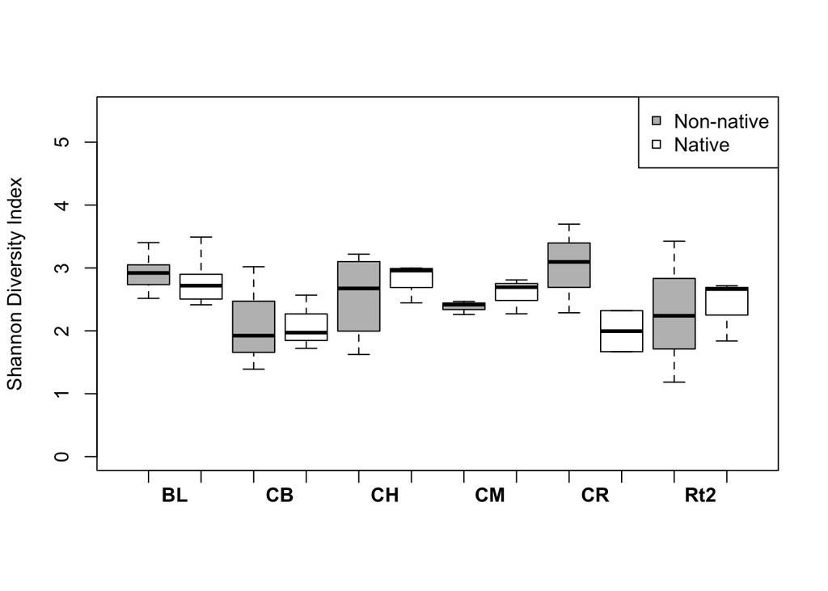

Histograms show that shannon diversity is fairly normally distributed.

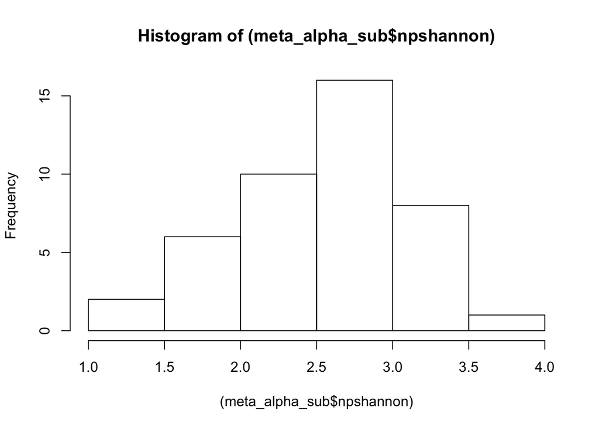

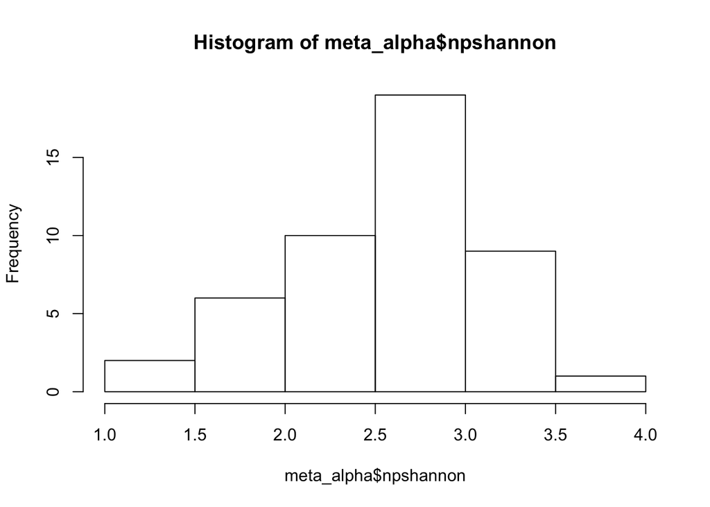

Assuming those are normally distributed, here are the results of an ANOVA by site and lineage. No significant difference in alpha diversity by site or lineage.

```
##              Df Sum Sq Mean Sq F value Pr(>F)
## Site          7  3.239  0.4627   1.567  0.182
## Lineage       1  0.014  0.0143   0.048  0.827
## Site:Lineage  7  1.647  0.2353   0.797  0.596
## Residuals    31  9.150  0.2952
```

## Community Analysis

### PerManova

The following is a PerMANOVA of phyloytpes by site and Lineage

```
##
## Call:
## adonis(formula = shared ~ Site * Lineage, data = meta_alpha,      method = "bray")
##
## Permutation: free
## Number of permutations: 999
##
## Terms added sequentially (first to last)
##
##              Df SumsOfSqs MeanSqs F.Model      R2 Pr(>F)
## Site          7    3.4949 0.49926 1.63479 0.23035  0.001 ***
## Lineage       1    0.2488 0.24885 0.81483 0.01640  0.660
## Site:Lineage  7    1.9611 0.28015 0.91733 0.12925  0.710
## Residuals    31    9.4674 0.30540         0.62400
## Total        46   15.1722                 1.00000
## ---
## Signif. codes:  0 '***' 0.001 '**' 0.01 '*' 0.05 '.' 0.1 ' ' 1
```

There is a significant *site* effect. Lineage and their interaction are non-significant.

### NMDS

The following is an NMDS (stress = 0.2548253) showing Lineage as different shapes and site by color. The ellipses are sd by site.

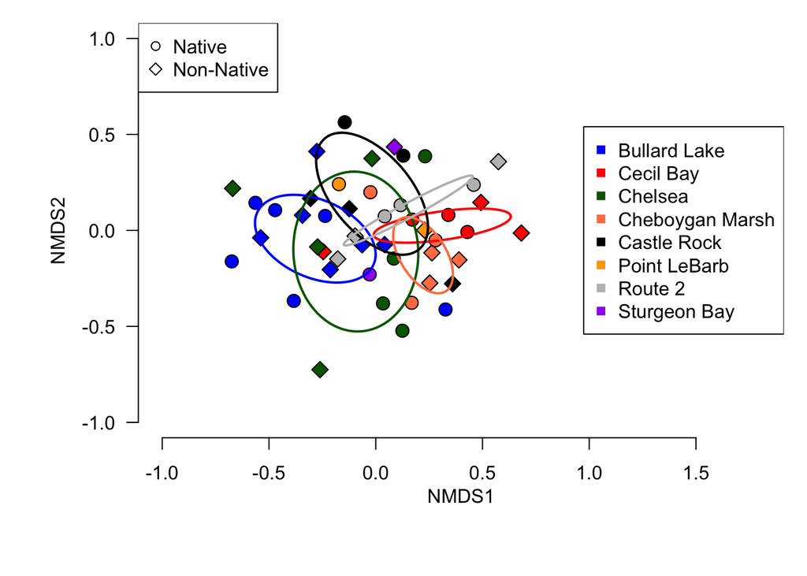

### Remove rare taxa

I removed rare taxa using relative abundance data. Any OTU that made up less than 0.1% of the total sequences was removed. This is more stringent than removing singletons, but ensures that rare taxa are not responsible for site effects. The following are results of a permanova of only abundant taxa by site and lineage.

```
##
## Call:
## adonis(formula = shared_abundant ~ Site * Lineage, data = meta_alpha)
##
## Permutation: free
## Number of permutations: 999
##
## Terms added sequentially (first to last)
##
##              Df SumsOfSqs MeanSqs F.Model      R2 Pr(>F)
## Site          7    3.4563 0.49375 1.65877 0.23310  0.001 ***
## Lineage       1    0.2419 0.24186 0.81255 0.01631  0.671
## Site:Lineage  7    1.9017 0.27167 0.91269 0.12826  0.735
## Residuals    31    9.2275 0.29766         0.62233
## Total        46   14.8274                 1.00000
## ---
## Signif. codes:  0 '***' 0.001 '**' 0.01 '*' 0.05 '.' 0.1 ' ' 1
```

Removing rare taxa reduced the total OTU number from 251 to 85

There is still a significant difference in the community using only abundant taxa.

I also performed a Kruskal-Wallace test to see if the relative abundance of any individual taxa differed by site or lineage. All tests were non-significant indicating that no individual otu relative abundances are significantly different by site or lineage

## Taxonomic Analysis

### By Phylum

The following show all fungal Phyla by relative sequence abundance

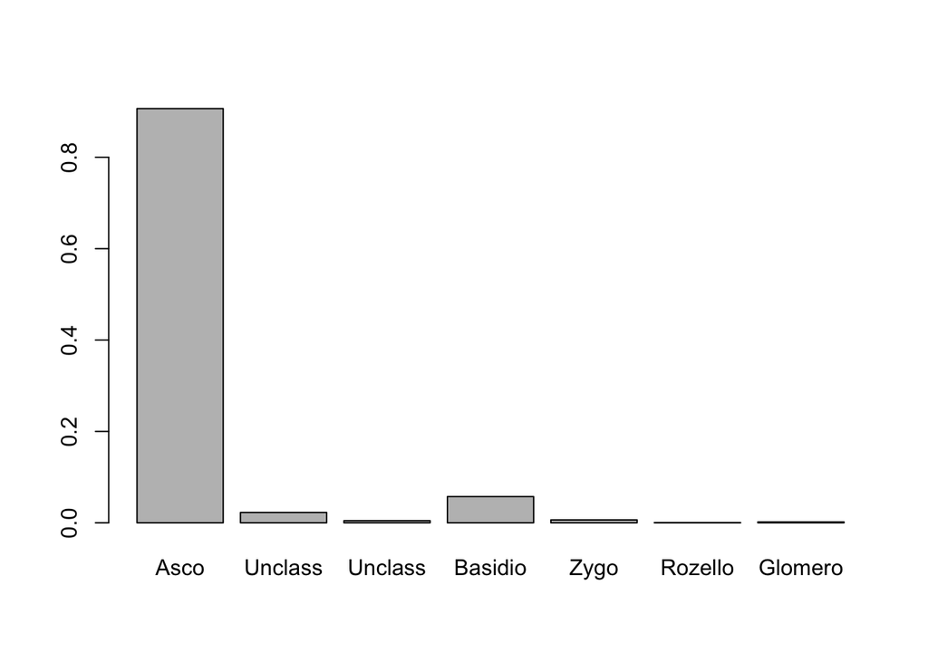

Ascomycota makes up 90.6595745% of the total sequences!

Glomeromycota makes up only 0.1914894%!!

### By Genus

The following is a plot of relative abundance by genus within Ascomycota. I have removed all genera that were unclassified. Unclassified genera made up 18.1253885% of the total Ascomycota.  
Only the genera with a relative abundance more than 1% of classified genera are displayed here.

```
##     Gibberella   Tetracladium   Microdochium      Cadophora   Stagonospora
##     0.19486053     0.13434370     0.10999786     0.09650205     0.07631646
##    Ilyonectria   Saccharicola       Fusarium    Aspergillus    Neobulgaria
##     0.06813237     0.03402079     0.03262032     0.02182322     0.01744832
##     Acremonium Mycosphaerella      Podospora  Monographella     Alternaria
##     0.01692489     0.01642912     0.01457909     0.01438796     0.01177699
```

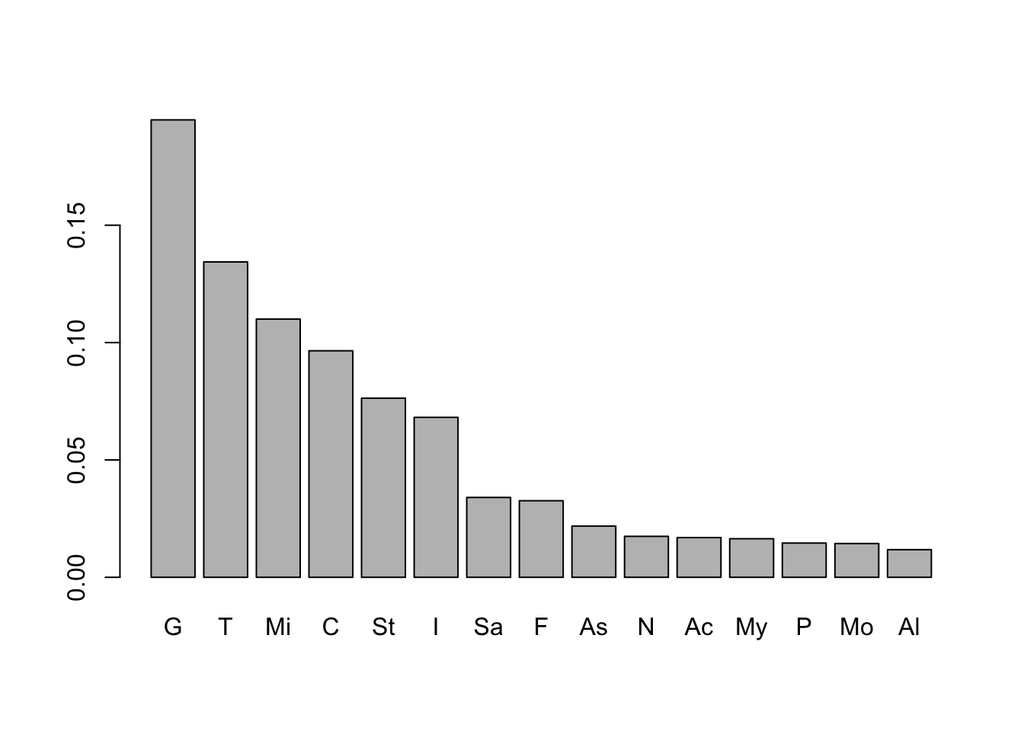

### By Function

I ran my taxonomy data through the FUNGuild database to get functional guilds for all taxa. Unclassified taxa were obviously not matched. FUNGuild gives trophic mode and Guild as outputs. Guild is nested within trophic mode, so I have shown the data by trophic mode, then guild

#### Trophic Mode

I created a plot of relative abundance by trophic mode

```
##                        Pathotroph                        Saprotroph
##                       0.481503782                       0.329748387
##            Pathotroph-Symbiotroph             Pathotroph-Saprotroph
##                       0.086647847                       0.083121403
##                       Symbiotroph Pathotroph-Saprotroph-Symbiotroph
##                       0.017543839                       0.001434742
```

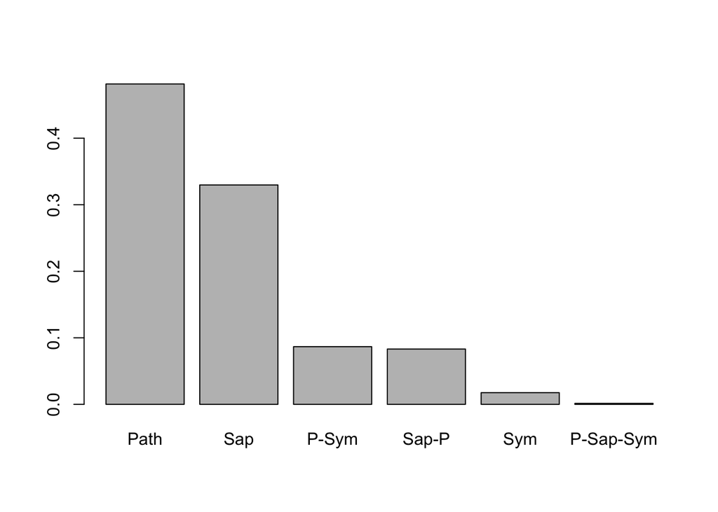

Pathogens are most abundant. The pathotroph-symbiotroph category is difficult to know what to do with. I assume they have been shown to have multiple trophic modes depending on the host.

##### Community by Trophic mode

Here is a community analysis by trophic mode. First I ran a Permanova to see if the sites had significatly different communities of trophic modes.

```
##
## Call:
## adonis(formula = trophic_shared ~ Site * Lineage, data = meta_alpha)
##
## Permutation: free
## Number of permutations: 999
##
## Terms added sequentially (first to last)
##
##              Df SumsOfSqs  MeanSqs F.Model      R2 Pr(>F)
## Site          7    1.0792 0.154175  2.3043 0.27262  0.010 **
## Lineage       1    0.0761 0.076057  1.1367 0.01921  0.309
## Site:Lineage  7    0.7293 0.104186  1.5571 0.18422  0.092 .
## Residuals    31    2.0742 0.066909         0.52395
## Total        46    3.9588                  1.00000
## ---
## Signif. codes:  0 '***' 0.001 '**' 0.01 '*' 0.05 '.' 0.1 ' ' 1
```

Here is an NMDS grouped by trophic mode (stress = 0.1925224)

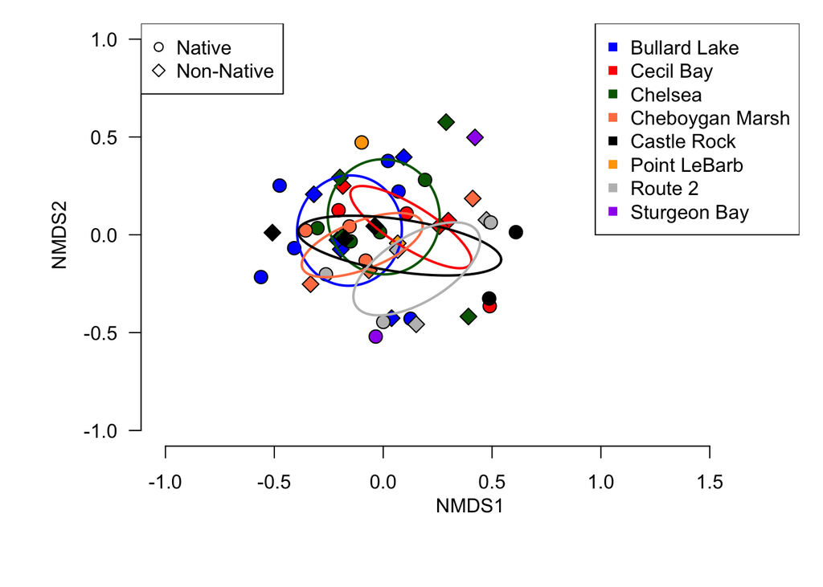

I performed Kruskel-Wallace tests to see if any individual trophic modes were significantly different by site. None were.

#### Guild

Here are the top 10 functional guilds by relative abundance. The bar plot is numbered by the most abundant to least. Refer to the list for guild names

```
##                                 Plant Pathogen
##                                    0.372692066
##                           Undefined Saprotroph
##                                    0.299353453
##                       Plant Pathogen-Endophyte
##                                    0.105820305
##                            Undefined Endophyte
##                                    0.086720047
## Plant Pathogen-Soil Saprotroph-Wood Saprotroph
##                                    0.031155827
##                     Animal Pathogen-Saprotroph
##                                    0.029032564
##                                Dung Saprotroph
##                                    0.021105054
##                                Ectomycorrhizal
##                                    0.014495417
##                 Plant Pathogen-Wood Saprotroph
##                                    0.014218544
##           Dung Saprotroph-Undefined Saprotroph
##                                    0.005794305
```

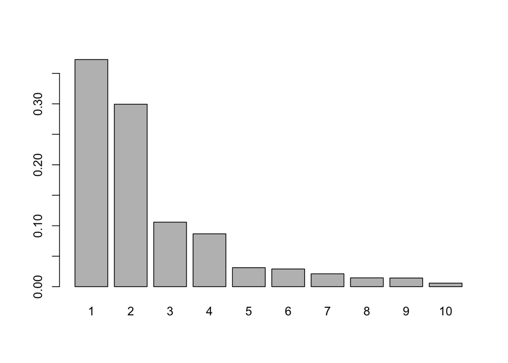

```
##
## Call:
## adonis(formula = all_guild_shared ~ Site * Lineage, data = meta_alpha)
##
## Permutation: free
## Number of permutations: 999
##
## Terms added sequentially (first to last)
##
##              Df SumsOfSqs  MeanSqs F.Model      R2 Pr(>F)
## Site          7    1.5759 0.225133 2.01855 0.25643  0.009 **
## Lineage       1    0.0483 0.048297 0.43303 0.00786  0.814
## Site:Lineage  7    1.0640 0.151996 1.36280 0.17312  0.120
## Residuals    31    3.4575 0.111532         0.56259
## Total        46    6.1457                  1.00000
## ---
## Signif. codes:  0 '***' 0.001 '**' 0.01 '*' 0.05 '.' 0.1 ' ' 1
```

The permanova by functional guild still shows significant difference by site

I performed Kruskel-Wallace tests to see if any individual guilds were significantly different by site. None were.

## Nutrients

### Soil Nutrients

plot NMDS scores against nitrogen content

```
##
## Call:
## lm(formula = ma_finite$SoilN ~ NMDS1 * NMDS2)
##
## Coefficients:
## (Intercept)        NMDS1        NMDS2  NMDS1:NMDS2
##      0.5824      -0.5604      -0.4220      -0.9414
```

```
##
## Call:
## lm(formula = ma_finite$SoilN ~ NMDS1 * NMDS2)
##
## Residuals:
##     Min      1Q  Median      3Q     Max
## -0.8353 -0.4675 -0.1387  0.1181  2.1365
##
## Coefficients:
##             Estimate Std. Error t value Pr(>|t|)
## (Intercept)   0.5824     0.1204   4.837 2.98e-05 ***
## NMDS1        -0.5604     0.3923  -1.428    0.163
## NMDS2        -0.4220     0.4634  -0.911    0.369
## NMDS1:NMDS2  -0.9414     1.7878  -0.527    0.602
## ---
## Signif. codes:  0 '***' 0.001 '**' 0.01 '*' 0.05 '.' 0.1 ' ' 1
##
## Residual standard error: 0.7091 on 33 degrees of freedom
## Multiple R-squared:  0.1009, Adjusted R-squared:  0.01915
## F-statistic: 1.234 on 3 and 33 DF,  p-value: 0.3129
```

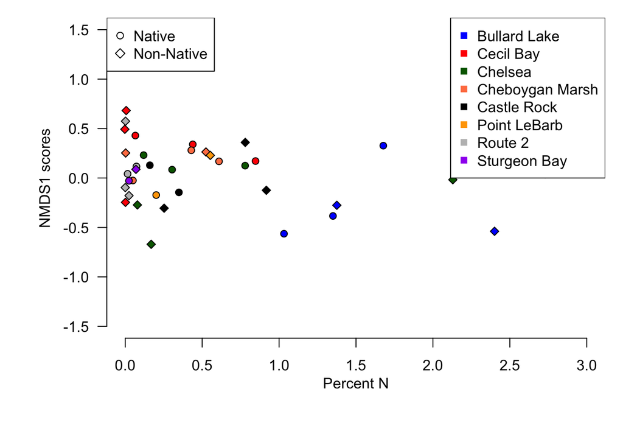

Now plot against P

```
##
## Call:
## lm(formula = ma_finite$SoilP ~ NMDS2 * NMDS1)
##
## Coefficients:
## (Intercept)        NMDS2        NMDS1  NMDS2:NMDS1
##       3.032       11.457       -2.733      -39.649
```

```
##
## Call:
## lm(formula = ma_finite$SoilP ~ NMDS2 * NMDS1)
##
## Residuals:
##     Min      1Q  Median      3Q     Max
## -12.714  -2.505  -1.288   0.468  41.158
##
## Coefficients:
##             Estimate Std. Error t value Pr(>|t|)
## (Intercept)    3.032      1.453   2.087   0.0447 *
## NMDS2         11.457      5.592   2.049   0.0485 *
## NMDS1         -2.733      4.734  -0.577   0.5677
## NMDS2:NMDS1  -39.649     21.572  -1.838   0.0751 .
## ---
## Signif. codes:  0 '***' 0.001 '**' 0.01 '*' 0.05 '.' 0.1 ' ' 1
##
## Residual standard error: 8.557 on 33 degrees of freedom
## Multiple R-squared:  0.196,  Adjusted R-squared:  0.1229
## F-statistic: 2.681 on 3 and 33 DF,  p-value: 0.0628
```

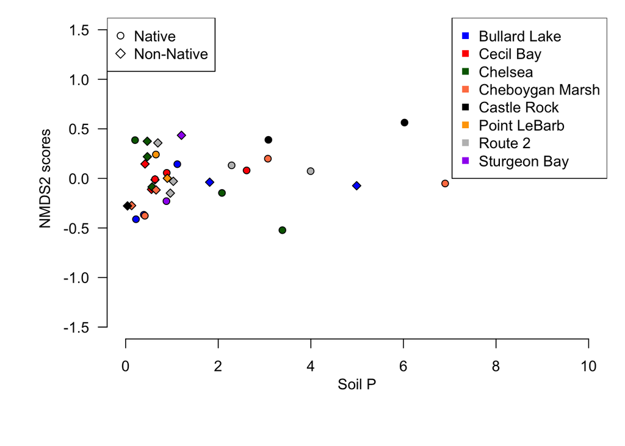

Adding nutrients into PerMANOVA

```
##
## Call:
## adonis(formula = shared_finite ~ SoilN + SoilP, data = ma_finite,      method = "bray")
##
## Permutation: free
## Number of permutations: 999
##
## Terms added sequentially (first to last)
##
##           Df SumsOfSqs MeanSqs F.Model      R2 Pr(>F)
## SoilN      1    0.4353 0.43532 1.34013 0.03692  0.163
## SoilP      1    0.3116 0.31158 0.95921 0.02643  0.540
## Residuals 34   11.0442 0.32483         0.93666
## Total     36   11.7911                 1.00000
```